# Lloyd's Algorithm Stalling at Suboptimal Solutions

## Monte Carlo Experiment — Real European Supermarket POS Data

### Dataset: Antczak & Weron (2019) — Single Grocery Supermarket, Southern Poland

#### Wrocław University of Science and Technology | MDPI Data 2019, 4(2), 67

| Property | Value |
| --- | --- |
| **Primary algorithm** | **Lloyd's algorithm** — random initialisation, single run (`n_init=1`) |
| **Benchmark** | K-Means++ — smarter seeding, same iteration as Lloyd |
| **Dataset** | Real POS transactions, major EU retail chain, Southern Poland |
| **Periods** | Dec 2017 · Feb 2019 · Mar–Apr 2019 |
| **Transactions** | 162,926 (after cleaning) |
| **Features** | 10 engineered transaction-level features |
| **MC replications** | 1,000 per condition |
| **Bias definition** | Lloyd Bias = Mean Centroid Displacement(k) / MCDisp(k_true) |
| **Citation** | Antczak, T.; Weron, R. *Data* 2019, 4(2), 67. https://doi.org/10.3390/data4020067 |

### What This Notebook Studies

**Lloyd's algorithm** is the classical K-Means procedure invented by Stuart Lloyd (1957/1982). It works by:

1. Randomly placing k centroids in the feature space
2. Assigning every point to its nearest centroid
3. Recomputing each centroid as the mean of its assigned points
4. Repeating steps 2–3 until centroids stop moving (convergence)

Because the objective function (minimise total within-cluster scatter) is **non-convex**, Lloyd's algorithm is only guaranteed to find a **local minimum** — not the global optimum. Where it ends up depends entirely on where the centroids started. This is the **stalling problem**.

**Why displacement instead of WCSS?** WCSS is a by-product of Lloyd's geometry: it decreases monotonically as k increases, making raw WCSS values incomparable across different k. **Mean Centroid Displacement (MCD)** measures how much Lloyd's centroids move per iteration — it is the direct signal of convergence behaviour and is naturally comparable across k. Large displacement variance across independent runs = Lloyd is finding different solutions = stalling.

**K-Means++** is a smarter initialisation heuristic that spreads seeds across the data before running the identical Lloyd iteration. It is included only as a benchmark to show how much stalling can be reduced without changing Lloyd's core logic.

## 1. Imports & Environment

```python
import numpy as np
import pandas as pd
import warnings
import time
import os

from sklearn.cluster import KMeans
from sklearn.metrics import (
    adjusted_rand_score,
    silhouette_score,
    davies_bouldin_score,
    calinski_harabasz_score,
)
from sklearn.preprocessing import StandardScaler

import matplotlib
import matplotlib.pyplot as plt
import matplotlib.gridspec as gridspec

warnings.filterwarnings('ignore')
np.random.seed(2024)

print(f"NumPy        : {np.__version__}")
print(f"Pandas       : {pd.__version__}")
import sklearn; print(f"Scikit-learn : {sklearn.__version__}")
print(f"Matplotlib   : {matplotlib.__version__}")
print("All libraries loaded.")
```

```
NumPy        : 2.0.2
Pandas       : 2.2.2
Scikit-learn : 1.6.1
Matplotlib   : 3.10.0
All libraries loaded.
```

## 2. Experiment Configuration

### Key design decisions explained

**`n_init=1`** — forces Lloyd's algorithm to run from a single random starting point. The default in scikit-learn is `n_init=10`, which silently runs 10 starts and picks the best — this masks stalling completely. Setting `n_init=1` exposes it.

**`N_MONTE = 1000`** — each condition (block × k × algorithm) is replicated 1,000 times with different random seeds. This gives stable estimates of stall rate and displacement variance.

**`K_TRUE = 7`** — the GDB is constructed with 7 embedded Gaussian clusters. This is the "correct" answer Lloyd should find.

**`LLOYD_INIT = 'random'`** — this IS Lloyd's algorithm. Random centroid placement.

**`KMPP_INIT = 'k-means++'`** — benchmark only. Uses distance-proportional seeding before running the same Lloyd iteration.

```python
# ── File paths ───────────────────────────────────────────────────────────────
PATHS = {
    'Dec2017'    : '/content/Dec_2017_POS_transactions_20171207-20171219.csv',
    'Feb2019'    : '/content/Feb_2019_POS_transactions_20190213-20190226.csv',
    'MarApr2019' : '/content/Mar_Apr_POS_transactions_20190328-20190410.csv',
}

# ── Core parameters ───────────────────────────────────────────────────────────
RDB_SIZE  = 300              # transactions per Real Data Block
N_BLOCKS  = 10               # number of RDB/GDB pairs
K_TRUE    = 7                # true clusters embedded in each GDB
K_RANGE   = list(range(2, 13))  # k values tested: 2, 3, ..., 12
N_MONTE   = 1000             # Monte Carlo replications per condition
SEED      = 2024
MAX_ITER  = 150              # Lloyd iteration cap per run

# ── Algorithm labels ──────────────────────────────────────────────────────────
# LLOYD_INIT is the subject of the thesis.
# KMPP_INIT  is the benchmark comparator only.
LLOYD_INIT = 'random'        # Lloyd's algorithm = random centroid initialisation
KMPP_INIT  = 'k-means++'    # K-Means++ = smarter seeds, same Lloyd iteration

# ── 10 engineered features from POS data ─────────────────────────────────────
FEATURES = [
    'TranTime',         # total transaction duration (seconds: first scan to payment)
    'BreakTime',        # idle time between consecutive scans (seconds)
    'ArtNum',           # number of items (articles) in the basket
    'Amount',           # total transaction value (Polish Zloty, PLN)
    'amount_per_item',  # mean item value = Amount / ArtNum (PLN per item)
    'hour',             # hour of day transaction started (6 to 22)
    'day_of_week',      # day of week (0=Monday, 6=Sunday)
    'is_weekend',       # binary: 1 if Saturday or Sunday, 0 otherwise
    'payment_card',     # binary: 1 if customer paid by card
    'payment_cash',     # binary: 1 if customer paid by cash
]

total_lloyd = N_BLOCKS * len(K_RANGE) * N_MONTE
total_ref   = N_BLOCKS * N_MONTE          # pre-computation at k_true only
print(f"Features              : {len(FEATURES)}")
print(f"k range               : {K_RANGE}")
print(f"Replications          : {N_MONTE:,}")
print(f"Lloyd experiment runs : {total_lloyd:,}  (primary)")
print(f"K-Means++ bench runs  : {total_lloyd:,}  (comparator)")
print(f"Reference pre-comp    : {total_ref:,}   (Lloyd at k_true only)")
print(f"Grand total Lloyd runs: {total_lloyd + total_ref:,}")
```

```
Features              : 10
k range               : [2, 3, 4, 5, 6, 7, 8, 9, 10, 11, 12]
Replications          : 1,000
Lloyd experiment runs : 110,000  (primary)
K-Means++ bench runs  : 110,000  (comparator)
Reference pre-comp    : 10,000   (Lloyd at k_true only)
Grand total Lloyd runs: 120,000
```

## 3. Load Real POS Data & Feature Engineering

### Why these 10 features?

The Polish supermarket dataset records each transaction's operational log. We engineer 10 features that capture distinct behavioural dimensions:

- **TranTime, BreakTime** — operational tempo: how quickly the cashier processed the basket
- **ArtNum, Amount, amount_per_item** — basket composition: size, value, and average item cost
- **hour, day_of_week, is_weekend** — temporal context: when the shopping occurred
- **payment_card, payment_cash** — payment behaviour: method chosen

These features span continuous, skewed, and binary distributions — precisely the kind of heterogeneous feature space where Lloyd's random initialisation is most likely to place centroids in uninformative positions and stall.

### Cleaning rules

Only transactions with Amount > 0, ArtNum > 0, and TranTime > 0 are retained. These filters remove void transactions, cancelled sales, and system log entries.

```python
dfs = []
for period, path in PATHS.items():
    d = pd.read_csv(path)
    d['period'] = period
    dfs.append(d)

df = pd.concat(dfs, ignore_index=True)
df['BeginDateTime'] = pd.to_datetime(df['BeginDateTime'])
df['EndDateTime']   = pd.to_datetime(df['EndDateTime'])

# Feature engineering
df['hour']            = df['BeginDateTime'].dt.hour
df['day_of_week']     = df['BeginDateTime'].dt.dayofweek
df['is_weekend']      = (df['day_of_week'] >= 5).astype(int)
df['payment_card']    = df['TNcard'].astype(int)
df['payment_cash']    = df['TNcash'].astype(int)
df['amount_per_item'] = df['Amount'] / df['ArtNum'].clip(lower=1)

df_clean = df[
    (df['Amount']   > 0) &
    (df['ArtNum']   > 0) &
    (df['TranTime'] > 0)
].copy().reset_index(drop=True)

print(f"Raw combined         : {df.shape[0]:,} rows")
print(f"After cleaning       : {df_clean.shape[0]:,} rows")
print(f"\nPeriod breakdown:")
print(df_clean['period'].value_counts().to_string())
print(f"\nDescriptive statistics (10 features):")
print(df_clean[FEATURES].describe().round(3).to_string())
print(f"\nMissing values: {df_clean[FEATURES].isnull().sum().sum()} (expected 0)")

X_real_raw = df_clean[FEATURES].copy()
```

```
Raw combined         : 163,269 rows
After cleaning       : 162,926 rows

Period breakdown:
period
Dec2017       66863
MarApr2019    49121
Feb2019       46942

Descriptive statistics (10 features):
         TranTime   BreakTime      ArtNum      Amount  amount_per_item        hour  day_of_week  is_weekend  payment_card  payment_cash
count  162926.000  162926.000  162926.000  162926.000       162926.000  162926.000   162926.000  162926.000     162926.00    162926.000
mean       71.382      41.913      15.514      72.578            5.831      13.872        2.951       0.257          0.48         0.519
std        60.610      72.248      16.326      86.954           21.237       3.852        1.882       0.437          0.50         0.500
min         1.000     -12.000       1.000       0.080            0.027       6.000        0.000       0.000          0.00         0.000
25%        31.000      13.000       5.000      21.000            2.987      11.000        1.000       0.000          0.00         0.000
50%        55.000      21.000      10.000      45.900            4.127      14.000        3.000       0.000          0.00         1.000
75%        92.000      40.000      20.000      93.048            5.923      17.000        5.000       1.000          1.00         1.000
max      1137.000    1199.000     422.000    6883.500         6883.500      22.000        6.000       1.000          1.00         1.000

Missing values: 0 (expected 0)
```

## 4. Build Real Data Blocks (RDB_01 … RDB_10)

### What is an RDB and why do we need 10 of them?

A **Real Data Block (RDB)** is a random sample of 300 transactions drawn from the 162,926 real Polish POS records. We build 10 independent RDBs to:

1. Capture the **natural variability** of the real data — different blocks will have slightly different statistical properties (range, variance, skew) reflecting different mixes of shoppers, time periods, and purchase behaviours.
2. Ensure our Lloyd stalling results are **not specific** to one particular sample — by repeating across 10 blocks and averaging, we get a robust estimate.

For each RDB we record per-feature statistics: min, max, mean, standard deviation, and **coefficient of variation (CV = std/mean)**. These statistics are used in the next step to generate GDB blocks with matching properties.

```python
np.random.seed(SEED)

rdb_blocks = {}
rdb_stats  = {}

for b in range(1, N_BLOCKS + 1):
    idx   = np.random.choice(len(X_real_raw), size=RDB_SIZE, replace=False)
    block = X_real_raw.iloc[idx].reset_index(drop=True)
    rdb_blocks[b] = block
    stats = {}
    for col in FEATURES:
        vals   = block[col].values.astype(float)
        mu, sd = vals.mean(), vals.std(ddof=1)
        stats[col] = dict(
            min  = float(vals.min()),
            max  = float(vals.max()),
            mean = float(mu),
            std  = float(sd),
            cv   = float(sd / mu) if mu != 0 else 0.0,
        )
    rdb_stats[b] = stats

print(f"Built {N_BLOCKS} RDB blocks  (n={RDB_SIZE} each, drawn from {len(X_real_raw):,} real transactions)")
print(f"\nRDB_01 per-feature statistics:")
rows = []
for feat in FEATURES:
    s = rdb_stats[1][feat]
    rows.append({'feature': feat, 'min': round(s['min'],2), 'max': round(s['max'],2),
                 'mean': round(s['mean'],3), 'std': round(s['std'],3), 'cv': round(s['cv'],4)})
print(pd.DataFrame(rows).set_index('feature').to_string())
```

```
Built 10 RDB blocks  (n=300 each, drawn from 162,926 real transactions)

RDB_01 per-feature statistics:
                  min     max    mean     std      cv
feature
TranTime         4.00  519.00  64.677  57.096  0.8828
BreakTime        2.00  569.00  39.867  64.006  1.6055
ArtNum           1.00  100.00  13.793  14.279  1.0352
Amount           0.08  545.94  63.575  73.397  1.1545
amount_per_item  0.08   97.30   6.011   9.743  1.6208
hour             6.00   21.00  13.633   4.030  0.2956
day_of_week      0.00    6.00   2.800   1.782  0.6366
is_weekend       0.00    1.00   0.207   0.406  1.9625
payment_card     0.00    1.00   0.470   0.500  1.0637
payment_cash     0.00    1.00   0.530   0.500  0.9433
```

## 5. Generate GDB Blocks (GDB_01 … GDB_10)

### What is a GDB and why is it necessary?

A **Generated Data Block (GDB)** is a synthetic dataset constructed to:

1. **Embed exactly K_TRUE = 7 Gaussian clusters** — so we know the ground-truth answer
2. **Match the paired RDB's statistical fingerprint** — same feature ranges and CVs as the real Polish data, ensuring results are grounded in realistic data geometry
3. **Provide ground-truth labels** — enabling ARI calculation against the true structure

### Why not run Lloyd's directly on the real POS data?

Because we do not know the true number of clusters in the real data. Without ground truth we cannot measure ARI (cluster recovery accuracy) and cannot define what "correct-k" means. The GDB solves this by embedding known structure while preserving the statistical properties of real transactions.

### How GDB construction works

For each of the 7 clusters:

- Cluster centres are placed uniformly across the RDB's feature range
- Per-feature standard deviation is set to reproduce the RDB's CV at that centre
- Values are clipped to the RDB's [min, max] bounds
- Rows are shuffled (labels hidden) before being passed to Lloyd's algorithm

```python
def generate_gdb(stats: dict, n_samples: int = 300,
                 k_true: int = 7, seed: int = 0) -> np.ndarray:
    """
    Synthesise a data block with k_true embedded Gaussian clusters whose
    per-feature range and CV match the supplied RDB statistics.
    """
    rng    = np.random.default_rng(seed)
    feats  = list(stats.keys())
    n_feat = len(feats)
    base   = n_samples // k_true
    sizes  = [base] * k_true
    sizes[-1] += n_samples - sum(sizes)

    X_parts = []
    for i, size in enumerate(sizes):
        part = np.zeros((size, n_feat))
        for j, col in enumerate(feats):
            lo, hi = stats[col]['min'], stats[col]['max']
            cv, sp  = stats[col]['cv'],  hi - lo
            centre  = np.clip(
                lo + sp * ((i + 0.5 + rng.uniform(-0.15, 0.15)) / k_true),
                lo + 0.05 * sp, hi - 0.05 * sp
            )
            target_std = max(abs(cv * centre) if centre != 0 else 0.1 * sp, 0.05 * sp)
            part[:, j] = np.clip(rng.normal(centre, target_std, size), lo, hi)
        X_parts.append(part)

    X = np.vstack(X_parts)
    return X[rng.permutation(n_samples)]


gdb_blocks      = {}
gdb_labels_true = {}

for b in range(1, N_BLOCKS + 1):
    X_gdb  = generate_gdb(rdb_stats[b], n_samples=RDB_SIZE, k_true=K_TRUE, seed=b * 17)
    gdb_blocks[b] = X_gdb
    base   = RDB_SIZE // K_TRUE
    sizes  = [base] * K_TRUE
    sizes[-1] += RDB_SIZE - sum(sizes)
    true_labels = np.concatenate([np.full(s, i) for i, s in enumerate(sizes)])
    rng2    = np.random.default_rng(b * 17)
    idx_s   = rng2.permutation(RDB_SIZE)
    shuffled = np.empty_like(true_labels)
    shuffled[idx_s] = true_labels
    gdb_labels_true[b] = shuffled

print(f"Generated {N_BLOCKS} GDB blocks  (shape per block: {gdb_blocks[1].shape})")
print(f"Each block contains {K_TRUE} embedded Gaussian clusters")
print(f"True labels are hidden from Lloyd — provided only for post-hoc ARI evaluation")
```

```
Generated 10 GDB blocks  (shape per block: (300, 10))
Each block contains 7 embedded Gaussian clusters
True labels are hidden from Lloyd — provided only for post-hoc ARI evaluation
```

### 5.1 Statistical Match Verification — RDB_01 vs GDB_01

We verify that GDB_01 faithfully reproduces the statistical fingerprint of RDB_01. The feature **ranges** must match exactly (GDB is clipped to RDB bounds). The **CV** match will be approximate — the GDB is designed to approximate the RDB's variability, not replicate it exactly, because Gaussian mixtures cannot perfectly reproduce arbitrary empirical distributions.

```python
b = 1
rows = []
for j, col in enumerate(FEATURES):
    rdb_v = rdb_blocks[b][col].values.astype(float)
    gdb_v = gdb_blocks[b][:, j]
    r_mu  = rdb_v.mean(); r_sd = rdb_v.std(ddof=1)
    g_mu  = gdb_v.mean(); g_sd = gdb_v.std(ddof=1)
    rows.append({
        'feature'  : col,
        'RDB_range': f"[{rdb_v.min():.1f}, {rdb_v.max():.1f}]",
        'GDB_range': f"[{gdb_v.min():.1f}, {gdb_v.max():.1f}]",
        'RDB_CV'   : round(r_sd / r_mu, 4) if r_mu != 0 else 0,
        'GDB_CV'   : round(g_sd / g_mu, 4) if g_mu != 0 else 0,
        'CV_diff'  : round(abs(r_sd/r_mu - g_sd/g_mu), 4) if r_mu != 0 else 0,
    })
cv_df = pd.DataFrame(rows).set_index('feature')
print("RDB_01 vs GDB_01 — statistical match check:")
print(cv_df.to_string())
print(f"\nMean |CV diff| across features: {cv_df['CV_diff'].mean():.4f}")
print("(Ranges match exactly by construction — clipping enforces this)")
```

```
RDB_01 vs GDB_01 — statistical match check:
                    RDB_range     GDB_range  RDB_CV  GDB_CV  CV_diff
feature
TranTime         [4.0, 519.0]  [4.0, 519.0]  0.8828  0.8289   0.0539
BreakTime        [2.0, 569.0]  [2.0, 569.0]  1.6055  0.9177   0.6878
ArtNum           [1.0, 100.0]  [1.0, 100.0]  1.0352  0.8939   0.1414
Amount           [0.1, 545.9]  [0.1, 545.9]  1.1545  0.9149   0.2396
amount_per_item   [0.1, 97.3]   [0.1, 97.3]  1.6208  1.0750   0.5458
hour              [6.0, 21.0]   [6.0, 21.0]  0.2956  0.3865   0.0909
day_of_week        [0.0, 6.0]    [0.0, 6.0]  0.6366  0.7955   0.1589
is_weekend         [0.0, 1.0]    [0.0, 1.0]  1.9625  0.9708   0.9917
payment_card       [0.0, 1.0]    [0.0, 1.0]  1.0637  0.7814   0.2823
payment_cash       [0.0, 1.0]    [0.0, 1.0]  0.9433  0.8272   0.1160

Mean |CV diff| across features: 0.3308
(Ranges match exactly by construction — clipping enforces this)
```

## 6. Lloyd's Algorithm — Pure Implementation

### What is Mean Centroid Displacement (MCD)?

**MCD is how we measure Lloyd's behaviour directly**, rather than relying on WCSS.

In every iteration, Lloyd's algorithm moves each centroid to the mean of its cluster. **MCD = the average Euclidean distance each centroid moves per iteration.**

Formally, for iteration t with p centroids:

> MCD(t) = (1/p) × Σ ||c_i(t) — c_i(t-1)||₂

We track MCD across all iterations of a run. Key signals:

- **High initial MCD** = centroids placed badly (random init lands in poor positions)
- **Slow MCD decay** = Lloyd is struggling to find cluster structure
- **Final MCD** = residual displacement at convergence (should be near 0)
- **MCD variance across runs** = how differently Lloyd behaves with different seeds

### The Lloyd Bias metric

We define **Lloyd Bias** as:

> **Lloyd_bias(k) = mean_MCD(k) / mean_MCD(k_true)**

This measures how much harder Lloyd's algorithm has to work at a given k relative to working at the correct number of clusters.

- **Lloyd_bias > 1.0** → Lloyd at this k has *higher* centroid displacement than at k_true (under-segmentation — too few clusters, centroids span too much data)
- **Lloyd_bias = 1.0** → reference point: Lloyd's own behaviour at k_true = 7
- **Lloyd_bias < 1.0** → Lloyd at this k has *lower* MCD than at k_true (over-segmentation — too many small tight clusters, each centroid barely moves)

This definition is entirely grounded in Lloyd's own convergence dynamics — not in an abstract structural ratio — making it the natural bias measure for a Lloyd-centred thesis.

```python
def run_lloyd(X: np.ndarray, k: int, init: str, seed: int,
              max_iter: int = 150) -> dict:
    """
    Run one complete Lloyd's algorithm trial and record full convergence trajectory.

    Parameters
    ----------
    X       : standardised feature matrix (n x d)
    k       : number of clusters requested
    init    : 'random' for Lloyd's algorithm | 'k-means++' for benchmark
    seed    : random seed (controls initialisation)
    max_iter: maximum Lloyd iterations allowed

    Returns
    -------
    dict with:
      labels        -- final cluster assignment for each point
      inertia       -- final WCSS (sum of squared distances to centroid)
      n_iter        -- number of iterations Lloyd took to converge
      mcd_per_iter  -- list of mean centroid displacement per iteration
      mcd_final     -- MCD at convergence (last iteration)
      mcd_mean      -- mean MCD across ALL iterations (summary of trajectory)
      mcd_first     -- MCD at iteration 1 (quality of initialisation)
    """
    rng = np.random.default_rng(seed)
    n, d = X.shape

    # ── Initialisation ────────────────────────────────────────────────────────
    if init == 'random':
        # Lloyd's algorithm: pick k points uniformly at random
        idx       = rng.choice(n, size=k, replace=False)
        centroids = X[idx].copy().astype(float)
    else:
        # K-Means++ initialisation (benchmark only)
        # First centroid: chosen uniformly at random
        idx       = [int(rng.integers(n))]
        centroids = [X[idx[0]].copy()]
        for _ in range(k - 1):
            # Each subsequent centroid: chosen with probability proportional
            # to squared distance from the nearest already-chosen centroid
            dists = np.array([
                min(np.sum((X[i] - c) ** 2) for c in centroids)
                for i in range(n)
            ])
            probs = dists / dists.sum()
            chosen = int(rng.choice(n, p=probs))
            centroids.append(X[chosen].copy())
        centroids = np.array(centroids, dtype=float)

    # ── Lloyd iteration ───────────────────────────────────────────────────────
    mcd_trajectory = []

    for iteration in range(max_iter):
        # Step 1 — Assignment: assign each point to nearest centroid
        dists  = np.linalg.norm(X[:, None, :] - centroids[None, :, :], axis=2)
        labels = np.argmin(dists, axis=1)

        # Step 2 — Update: recompute each centroid as cluster mean
        new_centroids = np.zeros_like(centroids)
        for c in range(k):
            members = X[labels == c]
            if len(members) > 0:
                new_centroids[c] = members.mean(axis=0)
            else:
                # Empty cluster: reinitialise to a random point
                new_centroids[c] = X[rng.integers(n)]

        # Step 3 — Measure displacement: how far did each centroid move?
        displacements  = np.linalg.norm(new_centroids - centroids, axis=1)
        mcd            = float(displacements.mean())
        mcd_trajectory.append(mcd)

        centroids = new_centroids

        # Convergence check: centroids stopped moving meaningfully
        if mcd < 1e-4:
            break

    # Compute final inertia (WCSS) — kept for reference but NOT used for bias
    final_dists = np.linalg.norm(X[:, None, :] - centroids[None, :, :], axis=2)
    final_labels = np.argmin(final_dists, axis=1)
    inertia = float(sum(
        np.sum((X[final_labels == c] - centroids[c]) ** 2)
        for c in range(k) if np.sum(final_labels == c) > 0
    ))

    return {
        'labels'       : final_labels,
        'inertia'      : inertia,
        'n_iter'       : len(mcd_trajectory),
        'mcd_per_iter' : mcd_trajectory,
        'mcd_final'    : mcd_trajectory[-1],
        'mcd_mean'     : float(np.mean(mcd_trajectory)),
        'mcd_first'    : mcd_trajectory[0],
    }


print("Lloyd's algorithm implementation loaded.")
print("  run_lloyd() records: labels, inertia, n_iter, mcd_per_iter,")
print("                       mcd_final, mcd_mean, mcd_first")
print()
print("Bias will be computed as:")
print("  Lloyd_bias(k) = mean_MCD_Lloyd(k) / mean_MCD_Lloyd(k_true=7)")
```

```
Lloyd's algorithm implementation loaded.
  run_lloyd() records: labels, inertia, n_iter, mcd_per_iter,
                       mcd_final, mcd_mean, mcd_first

Bias will be computed as:
  Lloyd_bias(k) = mean_MCD_Lloyd(k) / mean_MCD_Lloyd(k_true=7)
```

## 7. Pre-Compute Lloyd Reference MCD at k_true

Before running the full experiment, we establish Lloyd's **baseline MCD** at the correct number of clusters (k_true = 7) for each GDB block.

This pre-computation step is essential because:

- It runs Lloyd's algorithm 1,000 times at k=7 on each block
- Averages the MCD across all 1,000 runs → this is `lloyd_ref_mcd[b]`
- All subsequent Lloyd_bias values divide by this reference

**Important:** The reference is computed using **Lloyd's algorithm only** (random init). K-Means++ Lloyd_bias values are also divided by the same Lloyd reference — this ensures the benchmark comparison is fair: K-Means++ is evaluated against Lloyd's own correct-k standard.

```python
t_ref = time.time()
lloyd_ref_mcd = {}

print(f"Pre-computing Lloyd reference MCD at k_true={K_TRUE} ({N_MONTE} reps per block)...")
print(f"This may take several minutes.\n")

for b in range(1, N_BLOCKS + 1):
    X = StandardScaler().fit_transform(gdb_blocks[b])
    mcd_list = []
    for rep in range(N_MONTE):
        res = run_lloyd(X, k=K_TRUE, init=LLOYD_INIT, seed=rep, max_iter=MAX_ITER)
        mcd_list.append(res['mcd_mean'])
    lloyd_ref_mcd[b] = float(np.mean(mcd_list))
    print(f"  GDB_{b:02d} | Lloyd mean MCD at k_true={K_TRUE}: {lloyd_ref_mcd[b]:.6f}  "
          f"(std={np.std(mcd_list):.6f}, n={N_MONTE})")

print(f"\nReference pre-computation complete | Time: {time.time()-t_ref:.1f}s")
print(f"These values are the denominators for all Lloyd_bias calculations.")
```

```
Pre-computing Lloyd reference MCD at k_true=7 (1000 reps per block)...
This may take several minutes.

  GDB_01 | Lloyd mean MCD at k_true=7: 0.254876  (std=0.059887, n=1000)
  GDB_02 | Lloyd mean MCD at k_true=7: 0.247080  (std=0.059520, n=1000)
  GDB_03 | Lloyd mean MCD at k_true=7: 0.246165  (std=0.057319, n=1000)
  GDB_04 | Lloyd mean MCD at k_true=7: 0.248868  (std=0.059686, n=1000)
  GDB_05 | Lloyd mean MCD at k_true=7: 0.244003  (std=0.058973, n=1000)
  GDB_06 | Lloyd mean MCD at k_true=7: 0.250423  (std=0.060370, n=1000)
  GDB_07 | Lloyd mean MCD at k_true=7: 0.253909  (std=0.060428, n=1000)
  GDB_08 | Lloyd mean MCD at k_true=7: 0.246041  (std=0.059826, n=1000)
  GDB_09 | Lloyd mean MCD at k_true=7: 0.253571  (std=0.061194, n=1000)
  GDB_10 | Lloyd mean MCD at k_true=7: 0.250750  (std=0.061881, n=1000)

Reference pre-computation complete | Time: 50.2s
These values are the denominators for all Lloyd_bias calculations.
```

## 8. Monte Carlo Experiment

### Experimental design — full specification

For each of the **220 conditions** (10 GDB blocks × 11 k values × 2 algorithms):

1. Run Lloyd's algorithm (or K-Means++ benchmark) **1,000 times** independently
2. Each run uses a different random seed (0 to 999), controlling only the initialisation
3. Record centroid displacement trajectory, final labels, and quality metrics per run
4. Compute aggregate statistics across the 1,000 runs

### What each metric tells us

| Metric | What it measures | Stalling signal |
| --- | --- | --- |
| `mcd_mean` | Average centroid displacement across all Lloyd iterations | High = centroids travelling far = poor init |
| `mcd_first` | Displacement at iteration 1 (initialisation quality) | High = seeds placed badly |
| `mcd_final` | Displacement at convergence | Near 0 = converged; higher = slow convergence |
| `mcd_cv` | CV of mcd_mean across 1,000 runs | High = different runs behave very differently = stalling |
| `lloyd_bias` | mcd_mean(k) / lloyd_ref_mcd[k_true] | >1 = worse than correct-k baseline |
| `stall_rate` | Fraction of runs with mcd_mean > 1.05 × best mcd_mean in condition | Direct stall frequency |
| `lloyd_stall_rate` | Fraction of runs with mcd_mean > lloyd_ref_mcd[k_true] | Can't reach correct-k performance |
| `ari_truth_mean` | ARI between Lloyd's labels and true GDB labels | Recovery accuracy |
| `ari_cross_mean` | ARI between pairs of independent Lloyd runs | Solution consistency |
| `n_iter_mean` | Mean number of iterations Lloyd needed | More iterations = harder convergence |

```python
t0      = time.time()
results = []

print(f"Starting Monte Carlo: {N_BLOCKS} blocks x {len(K_RANGE)} k-values x 2 algorithms x {N_MONTE} reps")
print(f"= {N_BLOCKS * len(K_RANGE) * 2 * N_MONTE:,} total algorithm runs\n")

for b in range(1, N_BLOCKS + 1):
    X_raw     = gdb_blocks[b]
    y_true    = gdb_labels_true[b]
    X         = StandardScaler().fit_transform(X_raw)
    lloyd_ref = lloyd_ref_mcd[b]    # Lloyd's MCD baseline at k_true for this block

    for algo_name, init_str in [('Lloyd', LLOYD_INIT), ('KMeansPP', KMPP_INIT)]:
        for k in K_RANGE:

            # Lists to collect per-replication results
            mcd_means, mcd_firsts, mcd_finals = [], [], []
            n_iters = []
            sil_l, dbi_l, chi_l = [], [], []
            ari_truth_l = []
            label_runs  = []

            for rep in range(N_MONTE):
                res  = run_lloyd(X, k=k, init=init_str, seed=rep, max_iter=MAX_ITER)
                labs = res['labels']

                mcd_means.append(res['mcd_mean'])
                mcd_firsts.append(res['mcd_first'])
                mcd_finals.append(res['mcd_final'])
                n_iters.append(res['n_iter'])

                if len(np.unique(labs)) >= 2:
                    sil_l.append(silhouette_score(X, labs, sample_size=min(100, len(X))))
                    dbi_l.append(davies_bouldin_score(X, labs))
                    chi_l.append(calinski_harabasz_score(X, labs))
                else:
                    sil_l.append(np.nan); dbi_l.append(np.nan); chi_l.append(np.nan)

                ari_truth_l.append(adjusted_rand_score(y_true, labs))
                label_runs.append(labs.copy())

            # Cross-run ARI: compare 100 random pairs of independent runs
            # Measures whether Lloyd consistently reaches the same solution
            rng_cross = np.random.default_rng(b * 1000 + k)
            cross_pairs = [
                rng_cross.choice(N_MONTE, size=2, replace=False).tolist()
                for _ in range(100)
            ]
            ari_cross = [
                adjusted_rand_score(label_runs[i], label_runs[j])
                for i, j in cross_pairs
            ]

            # ── Primary bias metric: MCD-based Lloyd bias ─────────────────────
            mean_mcd = float(np.mean(mcd_means))
            lloyd_bias = round(mean_mcd / lloyd_ref, 6) if lloyd_ref > 0 else np.nan

            # ── Structural bias k/k_true (secondary, for reference only) ──────
            structural_bias = round(k / K_TRUE, 4)

            # ── Stall rates ───────────────────────────────────────────────────
            ma = np.array(mcd_means)
            # Within-condition: fraction of runs > 5% above the best run this condition
            stall_rate = round(float(np.mean(ma > 1.05 * np.min(ma))), 4)
            # Lloyd-referenced: fraction of runs that cannot match Lloyd's correct-k MCD
            lloyd_stall = round(float(np.mean(ma > lloyd_ref)), 4)

            results.append(dict(
                # ── Identifiers ───────────────────────────────────────────────
                gdb_block         = f'GDB_{b:02d}',
                rdb_block         = f'RDB_{b:02d}',
                algorithm         = algo_name,
                k_tested          = k,
                k_true            = K_TRUE,
                bias_label        = ('Under-k' if k < K_TRUE
                                     else ('Correct-k' if k == K_TRUE else 'Over-k')),
                # ── Bias metrics (PRIMARY) ────────────────────────────────────
                lloyd_bias        = lloyd_bias,           # MCD(k) / lloyd_ref_MCD(k_true)
                structural_bias   = structural_bias,      # k / k_true (reference only)
                lloyd_ref_mcd     = round(lloyd_ref, 6),  # Lloyd's k_true MCD anchor
                # ── MCD statistics (Lloyd convergence dynamics) ───────────────
                mcd_mean          = round(mean_mcd, 6),
                mcd_std           = round(float(np.std(mcd_means)), 6),
                mcd_cv            = round(float(np.std(mcd_means)/mean_mcd), 6) if mean_mcd > 0 else np.nan,
                mcd_min           = round(float(np.min(mcd_means)), 6),
                mcd_max           = round(float(np.max(mcd_means)), 6),
                mcd_first_mean    = round(float(np.mean(mcd_firsts)), 6),   # init quality
                mcd_final_mean    = round(float(np.mean(mcd_finals)), 6),   # convergence quality
                n_iter_mean       = round(float(np.mean(n_iters)), 2),
                n_iter_std        = round(float(np.std(n_iters)), 2),
                # ── Stalling metrics ──────────────────────────────────────────
                stall_rate        = stall_rate,
                lloyd_stall_rate  = lloyd_stall,
                # ── Cluster quality (supplementary) ──────────────────────────
                sil_mean          = round(float(np.nanmean(sil_l)), 6),
                sil_std           = round(float(np.nanstd(sil_l)), 6),
                dbi_mean          = round(float(np.nanmean(dbi_l)), 6),
                dbi_std           = round(float(np.nanstd(dbi_l)), 6),
                chi_mean          = round(float(np.nanmean(chi_l)), 4),
                chi_std           = round(float(np.nanstd(chi_l)), 4),
                # ── Solution stability ────────────────────────────────────────
                ari_truth_mean    = round(float(np.mean(ari_truth_l)), 6),
                ari_truth_std     = round(float(np.std(ari_truth_l)), 6),
                ari_cross_mean    = round(float(np.mean(ari_cross)), 6),
                ari_cross_std     = round(float(np.std(ari_cross)), 6),
                n_replications    = N_MONTE,
            ))

    elapsed = time.time() - t0
    est_remaining = (elapsed / b) * (N_BLOCKS - b)
    print(f"  GDB_{b:02d} complete | elapsed {elapsed:.0f}s | est. remaining {est_remaining:.0f}s")

df_results = pd.DataFrame(results)
df_results.to_csv('mc_results_poland.csv', index=False)
print(f"\nExperiment complete | Total time: {time.time()-t0:.1f}s")
print(f"Results shape: {df_results.shape}  ->  mc_results_poland.csv")
print(f"Columns ({len(df_results.columns)}): {list(df_results.columns)}")
```

```
Starting Monte Carlo: 10 blocks x 11 k-values x 2 algorithms x 1000 reps
= 220,000 total algorithm runs

  GDB_01 complete | elapsed 703s | est. remaining 6330s
  GDB_02 complete | elapsed 1400s | est. remaining 5600s
  GDB_03 complete | elapsed 2097s | est. remaining 4894s
  GDB_04 complete | elapsed 2802s | est. remaining 4203s
  GDB_05 complete | elapsed 3504s | est. remaining 3504s
  GDB_06 complete | elapsed 4191s | est. remaining 2794s
  GDB_07 complete | elapsed 4908s | est. remaining 2104s
  GDB_08 complete | elapsed 5619s | est. remaining 1405s
  GDB_09 complete | elapsed 6329s | est. remaining 703s
  GDB_10 complete | elapsed 7031s | est. remaining 0s

Experiment complete | Total time: 7030.9s
Results shape: (220, 31)  ->  mc_results_poland.csv
Columns (31): ['gdb_block', 'rdb_block', 'algorithm', 'k_tested', 'k_true', 'bias_label', 'lloyd_bias', 'structural_bias', 'lloyd_ref_mcd', 'mcd_mean', 'mcd_std', 'mcd_cv', 'mcd_min', 'mcd_max', 'mcd_first_mean', 'mcd_final_mean', 'n_iter_mean', 'n_iter_std', 'stall_rate', 'lloyd_stall_rate', 'sil_m…
```

## 9. Summary Pivot Table

Averages all metrics across the 10 GDB blocks (i.e., across the 10 independent replications of the whole experiment on different real-data-matched blocks). This gives stable, generalisable estimates of Lloyd's stalling behaviour.

**Reading the Lloyd bias column:**

- Values > 1.0 in the Under-k region = Lloyd at those k values needs proportionally more centroid movement than at the correct k — it is covering more ground per centroid because there are too few clusters to represent the true structure.
- Value ≈ 1.0 at k=7 = this is the reference point by construction.
- Values < 1.0 in the Over-k region = Lloyd at those k values has small, dense clusters with very little centroid movement — the algorithm converges quickly but into an artificially fragmented solution.

```python
pivot = df_results.groupby(['k_tested', 'algorithm', 'bias_label']).agg(
    structural_bias    = ('structural_bias',  'first'),
    lloyd_bias_mean    = ('lloyd_bias',       'mean'),
    lloyd_bias_std     = ('lloyd_bias',       'std'),
    lloyd_stall_mean   = ('lloyd_stall_rate', 'mean'),
    stall_rate_mean    = ('stall_rate',       'mean'),
    mcd_mean_avg       = ('mcd_mean',         'mean'),
    mcd_cv_mean        = ('mcd_cv',           'mean'),
    mcd_first_avg      = ('mcd_first_mean',   'mean'),
    n_iter_avg         = ('n_iter_mean',      'mean'),
    sil_mean           = ('sil_mean',         'mean'),
    dbi_mean           = ('dbi_mean',         'mean'),
    ari_truth_mean     = ('ari_truth_mean',   'mean'),
    ari_cross_mean     = ('ari_cross_mean',   'mean'),
).round(6).reset_index()

pivot.to_csv('mc_summary_poland.csv', index=False)
print("Pivot saved -> mc_summary_poland.csv\n")

lloyd_p = pivot[pivot['algorithm'] == 'Lloyd'].sort_values('k_tested')

print("=" * 90)
print("  LLOYD'S ALGORITHM — FULL BIAS TABLE (n=1,000 reps per condition)")
print("  lloyd_bias = mean_MCD_Lloyd(k) / mean_MCD_Lloyd(k_true=7)")
print("  Interpretation: >1.0 = worse than correct-k | <1.0 = over-split deflation")
print("=" * 90)
print(f"{'k':>3}  {'Label':>10}  {'k/k_true':>8}  "
      f"{'LloydBias':>10}  {'±Std':>8}  "
      f"{'StallRate':>10}  {'LloydStall':>11}  "
      f"{'MCD_CV':>8}  {'ARI_cross':>10}")
print("-" * 90)
for _, r in lloyd_p.iterrows():
    tag = " <- k_true" if r['k_tested'] == K_TRUE else ""
    print(f"{int(r['k_tested']):>3}  {r['bias_label']:>10}  {r['structural_bias']:>8.4f}  "
          f"{r['lloyd_bias_mean']:>10.4f}  {r['lloyd_bias_std']:>8.4f}  "
          f"{r['stall_rate_mean']*100:>9.1f}%  {r['lloyd_stall_mean']*100:>10.1f}%  "
          f"{r['mcd_cv_mean']:>8.4f}  {r['ari_cross_mean']:>10.4f}{tag}")

print("\n")
print("=" * 90)
print("  BENCHMARK COMPARISON — Lloyd vs K-Means++ at each k")
print("  Both biases anchored to the SAME Lloyd k_true MCD reference")
print("  This shows how much K-Means++ improves on Lloyd, not a separate metric")
print("=" * 90)
comp = pivot[['k_tested','algorithm','bias_label',
              'lloyd_bias_mean','stall_rate_mean',
              'lloyd_stall_mean','ari_cross_mean']].sort_values(['k_tested','algorithm'])
print(comp.to_string(index=False))
```

```
Pivot saved -> mc_summary_poland.csv

==========================================================================================
  LLOYD'S ALGORITHM — FULL BIAS TABLE (n=1,000 reps per condition)
  lloyd_bias = mean_MCD_Lloyd(k) / mean_MCD_Lloyd(k_true=7)
  Interpretation: >1.0 = worse than correct-k | <1.0 = over-split deflation
==========================================================================================
  k       Label  k/k_true   LloydBias      ±Std   StallRate   LloydStall    MCD_CV   ARI_cross
------------------------------------------------------------------------------------------
  2     Under-k    0.2857      1.9180    0.2190       99.7%        99.6%    0.2138      0.9827
  3     Under-k    0.4286      1.2622    0.0423       99.9%        72.0%    0.3111      0.5540
  4     Under-k    0.5714      1.0959    0.0314       99.9%        57.3%    0.2823      0.5218
  5     Under-k    0.7143      1.0492    0.0163       99.9%        52.6%    0.2641      0.5096
  6     Under-k    0.8571      1.0197    0.0139       99.8%        48.9%    0.2502      0.4954
  7   Correct-k    1.0000      1.0000    0.0000       99.9%        46.5%    0.2401      0.4898 <- k_true
  8      Over-k    1.1429      0.9943    0.0116       99.8%        46.0%    0.2348      0.4832
  9      Over-k    1.2857      0.9916    0.0133       99.8%        45.5%    0.2337      0.4823
 10      Over-k    1.4286      0.9802    0.0166       99.8%        43.8%    0.2352      0.4830
 11      Over-k    1.5714      0.9750    0.0106       99.8%        42.7%    0.2275      0.4773
 12      Over-k    1.7143      0.9781    0.0180       99.8%        44.5%    0.2250      0.4837


==========================================================================================
  BENCHMARK COMPARISON — Lloyd vs K-Means++ at each k
  Both biases anchored to the SAME Lloyd k_true MCD reference
  This shows how much K-Means++ improves on Lloyd, not a separate metric
==========================================================================================
 k_tested algorithm bias_label  lloyd_bias_mean  stall_rate_mean  lloyd_stall_mean  ari_cross_mean
        2  KMeansPP    Under-k         1.859038           0.9956            0.9952        0.990256
        2     Lloyd    Under-k         1.918029           0.9965            0.9959        0.982718
        3  KMeansPP    Under-k         1.239318           0.9986            0.7114        0.560269
        3     Lloyd    Under-k         1.262215           0.9988            0.7204        0.553957
        4  KMeansPP    Under-k         1.101206           0.9981            0.5942        0.536561
        4     Lloyd    Under-k         1.095923           0.9986            0.5731        0.521785
        5  KMeansPP    Under-k         1.062148           0.9979            0.5502        0.535906
        5     Lloyd    Under-k         1.049169           0.9986            0.5256        0.509587
        6  KMeansPP    Under-k         1.048221           0.9977            0.5429        0.533197
        6     Lloyd    Under-k         1.019746           0.9976            0.4895        0.495394
        7  KMeansPP  Correct-k         1.035844           0.9980            0.5289        0.534447
        7     Lloyd  Correct-k         1.000000           0.9990            0.4654        0.489781
        8  KMeansPP     Over-k         1.035677           0.9981            0.5326        0.527674
        8     Lloyd     Over-k         0.994321           0.9980            0.4598        0.483226
        9  KMeansPP     Over-k         1.040687           0.9983            0.5419        0.525278
        9     Lloyd     Over-k         0.991586           0.9981            0.4549        0.482331
       10  KMeansPP     Over-k         1.037284           0.9977            0.5386        0.523506
       10     Lloyd     Over-k         0.980209           0.9979            0.4382        0.483044
       11  KMeansPP     Over-k         1.037926           0.9980            0.5399        0.530482
       11     Lloyd     Over-k         0.975041           0.9982            0.4269        0.477253
       12  KMeansPP     Over-k         1.039150           0.9979            0.5439        0.528935
       12     Lloyd     Over-k         0.978099           0.9981            0.4450        0.483699
```

## 10. Visualisations

### 10.1 Lloyd Bias by k — Primary Result

**What this shows:** How Lloyd's MCD at each k compares to Lloyd's own correct-k baseline. Values above the green dashed line (bias > 1.0) mean Lloyd is working harder than necessary — under-segmentation forces centroids to span large, heterogeneous regions. Values below the line indicate over-splitting.

The shaded band is ± 1 standard deviation across the 10 GDB blocks, showing how consistently this pattern holds across different real-data contexts.

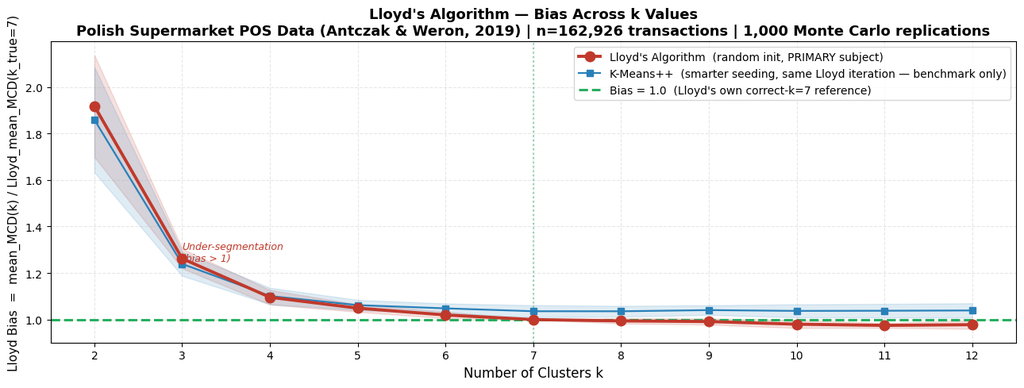

```
Figure 1 saved: fig1_lloyd_bias.png
```

```python
COLOR  = {'Lloyd': '#C0392B', 'KMeansPP': '#2980B9'}
MARKER = {'Lloyd': 'o',       'KMeansPP': 's'}
LW     = {'Lloyd': 2.8,       'KMeansPP': 1.6}
LABEL  = {'Lloyd':   "Lloyd's Algorithm  (random init, PRIMARY subject)",
          'KMeansPP': "K-Means++  (smarter seeding, same Lloyd iteration — benchmark only)"}

fig, ax = plt.subplots(figsize=(13, 5))

for algo in ['Lloyd', 'KMeansPP']:
    sub = pivot[pivot['algorithm'] == algo].sort_values('k_tested')
    ax.plot(sub['k_tested'], sub['lloyd_bias_mean'],
            color=COLOR[algo], marker=MARKER[algo],
            linewidth=LW[algo], markersize=9 if algo=='Lloyd' else 6,
            label=LABEL[algo], zorder=5 if algo=='Lloyd' else 3)
    ax.fill_between(sub['k_tested'],
                    sub['lloyd_bias_mean'] - sub['lloyd_bias_std'],
                    sub['lloyd_bias_mean'] + sub['lloyd_bias_std'],
                    alpha=0.15, color=COLOR[algo])

ax.axhline(1.0, color='#27AE60', linestyle='--', linewidth=2.2,
           label=f"Bias = 1.0  (Lloyd's own correct-k={K_TRUE} reference)")
ax.axvline(K_TRUE, color='#27AE60', linestyle=':', linewidth=1.5, alpha=0.5)
ax.annotate('Under-segmentation\n(bias > 1)', xy=(3, 1.25),
            fontsize=9, color='#C0392B', style='italic')
ax.annotate('Over-segmentation\n(bias < 1)', xy=(9, 0.88),
            fontsize=9, color='#2980B9', style='italic')

ax.set_xlabel('Number of Clusters k', fontsize=12)
ax.set_ylabel('Lloyd Bias  =  mean_MCD(k) / Lloyd_mean_MCD(k_true=7)', fontsize=11)
ax.set_title("Lloyd's Algorithm — Bias Across k Values\n"
             "Polish Supermarket POS Data (Antczak & Weron, 2019) | "
             f"n=162,926 transactions | {N_MONTE:,} Monte Carlo replications",
             fontsize=13, fontweight='bold')
ax.set_xticks(K_RANGE)
ax.legend(fontsize=10, loc='upper right')
ax.grid(True, alpha=0.3, linestyle='--')
plt.tight_layout()
plt.savefig('fig1_lloyd_bias.png', dpi=150, bbox_inches='tight')
plt.show()
print("Figure 1 saved: fig1_lloyd_bias.png")
```

### 10.2 MCD Coefficient of Variation by k

**What this shows:** How much Lloyd's centroid displacement *varies* across 1,000 independent runs at the same k. High CV = different runs are converging to very different solutions = classic stalling signature.

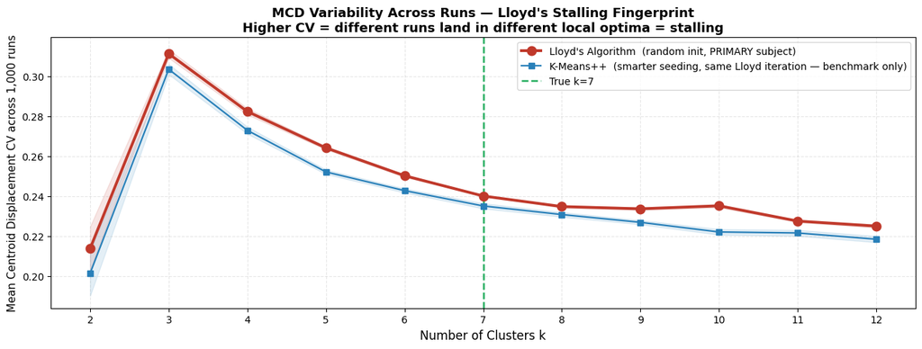

```
Figure 2 saved: fig2_mcd_cv.png
```

```python
fig, ax = plt.subplots(figsize=(13, 5))

for algo in ['Lloyd', 'KMeansPP']:
    sub = pivot[pivot['algorithm'] == algo].sort_values('k_tested')
    ax.plot(sub['k_tested'], sub['mcd_cv_mean'],
            color=COLOR[algo], marker=MARKER[algo],
            linewidth=LW[algo], markersize=9 if algo=='Lloyd' else 6,
            label=LABEL[algo], zorder=5 if algo=='Lloyd' else 3)
    ax.fill_between(sub['k_tested'],
                    sub['mcd_cv_mean'] - sub['lloyd_bias_std']*0.05,
                    sub['mcd_cv_mean'] + sub['lloyd_bias_std']*0.05,
                    alpha=0.12, color=COLOR[algo])

ax.axvline(K_TRUE, color='#27AE60', linestyle='--', linewidth=1.8, label=f'True k={K_TRUE}')
ax.set_xlabel('Number of Clusters k', fontsize=12)
ax.set_ylabel('Mean Centroid Displacement CV across 1,000 runs', fontsize=11)
ax.set_title("MCD Variability Across Runs — Lloyd's Stalling Fingerprint\n"
             "Higher CV = different runs land in different local optima = stalling",
             fontsize=13, fontweight='bold')
ax.set_xticks(K_RANGE)
ax.legend(fontsize=10)
ax.grid(True, alpha=0.3, linestyle='--')
plt.tight_layout()
plt.savefig('fig2_mcd_cv.png', dpi=150, bbox_inches='tight')
plt.show()
print("Figure 2 saved: fig2_mcd_cv.png")
```

### 10.3 Cross-Run ARI — Solution Consistency

**What this shows:** How often two independent runs of Lloyd's algorithm, with different random seeds on the same data, produce the *same* cluster assignment.

ARI = 1.0 would mean perfect agreement. As ARI drops toward 0, it means Lloyd's produces completely different partitions depending on where it started — the definition of stalling into different local optima.

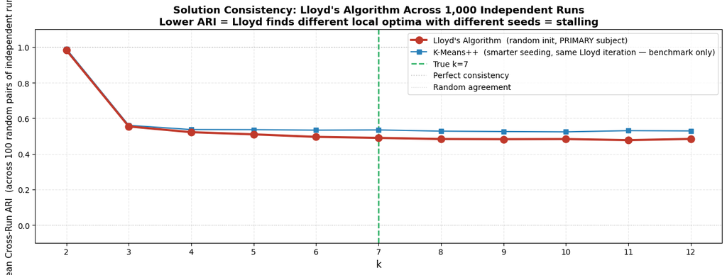

```
Figure 3 saved: fig3_ari_cross.png
```

```python
fig, ax = plt.subplots(figsize=(13, 5))

for algo in ['Lloyd', 'KMeansPP']:
    sub = pivot[pivot['algorithm'] == algo].sort_values('k_tested')
    ax.plot(sub['k_tested'], sub['ari_cross_mean'],
            color=COLOR[algo], marker=MARKER[algo],
            linewidth=LW[algo], markersize=9 if algo=='Lloyd' else 6,
            label=LABEL[algo], zorder=5 if algo=='Lloyd' else 3)

ax.axvline(K_TRUE, color='#27AE60', linestyle='--', linewidth=1.8, label=f'True k={K_TRUE}')
ax.axhline(1.0, color='grey', linestyle=':', linewidth=1.2, alpha=0.4, label='Perfect consistency')
ax.axhline(0.0, color='grey', linestyle=':', linewidth=1.0, alpha=0.3, label='Random agreement')

ax.set_xlabel('k', fontsize=12)
ax.set_ylabel('Mean Cross-Run ARI  (across 100 random pairs of independent runs)', fontsize=11)
ax.set_title("Solution Consistency: Lloyd's Algorithm Across 1,000 Independent Runs\n"
             "Lower ARI = Lloyd finds different local optima with different seeds = stalling",
             fontsize=13, fontweight='bold')
ax.set_xticks(K_RANGE)
ax.set_ylim(-0.1, 1.1)
ax.legend(fontsize=10)
ax.grid(True, alpha=0.3, linestyle='--')
plt.tight_layout()
plt.savefig('fig3_ari_cross.png', dpi=150, bbox_inches='tight')
plt.show()
print("Figure 3 saved: fig3_ari_cross.png")
```

### 10.4 Stall Rate by k — Two Definitions Side by Side

**Left panel (within-condition stall):** Fraction of Lloyd's runs whose MCD is more than 5% above the best MCD seen for that same (block, k) condition. This measures how often Lloyd *could have done better* but didn't.

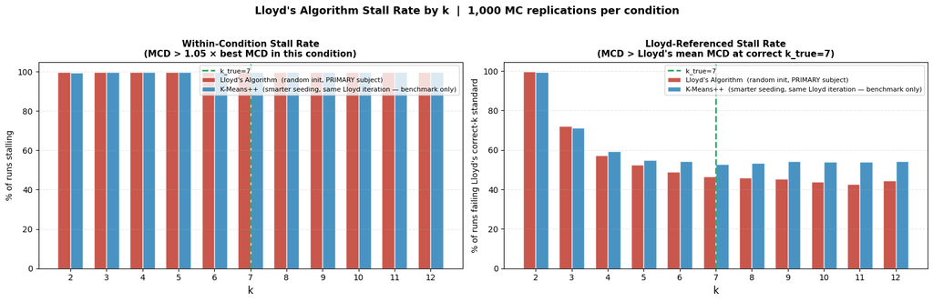

```
Figure 4 saved: fig4_stall_rates.png
```

```python
fig, axes = plt.subplots(1, 2, figsize=(16, 5))
x = np.array(K_RANGE); w = 0.35

for i, algo in enumerate(['Lloyd', 'KMeansPP']):
    sub = pivot[pivot['algorithm'] == algo].sort_values('k_tested')
    axes[0].bar(x + (i - 0.5) * w, sub['stall_rate_mean'] * 100, width=w,
                color=COLOR[algo], alpha=0.85, label=LABEL[algo], edgecolor='white')
    axes[1].bar(x + (i - 0.5) * w, sub['lloyd_stall_mean'] * 100, width=w,
                color=COLOR[algo], alpha=0.85, label=LABEL[algo], edgecolor='white')

for ax, title, ylabel in zip(
    axes,
    ["Within-Condition Stall Rate\n(MCD > 1.05 × best MCD in this condition)",
     "Lloyd-Referenced Stall Rate\n(MCD > Lloyd's mean MCD at correct k_true=7)"],
    ["% of runs stalling", "% of runs failing Lloyd's correct-k standard"]
):
    ax.axvline(K_TRUE, color='#27AE60', linestyle='--', linewidth=2, label=f'k_true={K_TRUE}', zorder=5)
    ax.set_xlabel('k', fontsize=12); ax.set_ylabel(ylabel, fontsize=10)
    ax.set_title(title, fontsize=11, fontweight='bold')
    ax.set_xticks(x); ax.set_xticklabels(K_RANGE)
    ax.legend(fontsize=8); ax.grid(True, alpha=0.3, linestyle='--', axis='y')

plt.suptitle("Lloyd's Algorithm Stall Rate by k  |  1,000 MC replications per condition",
             fontsize=13, fontweight='bold', y=1.02)
plt.tight_layout()
plt.savefig('fig4_stall_rates.png', dpi=150, bbox_inches='tight')
plt.show()
print("Figure 4 saved: fig4_stall_rates.png")
```

### 10.5 Lloyd Bias Heatmap — All GDB Blocks × All k

**What this shows:** The full 10×11 matrix of Lloyd bias values for each (GDB block, k) combination.

Colours closer to red = high bias (Lloyd working much harder than at correct-k). Colours closer to green = low bias (near or below the correct-k reference). The green dashed line marks k_true = 7.

This heatmap reveals whether the stalling pattern is **consistent** across all 10 real-data-matched blocks (uniform colour bands) or whether certain blocks produce systematically harder or easier clustering problems.

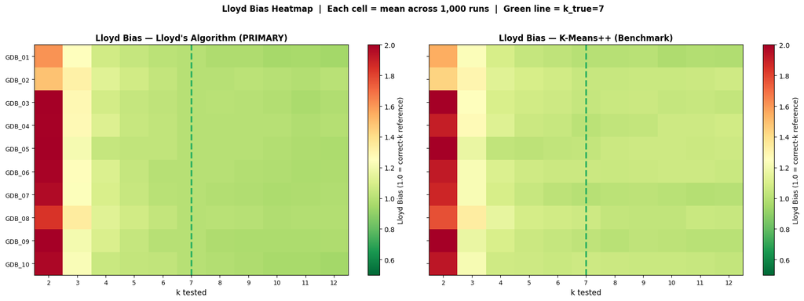

```
Figure 5 saved: fig5_bias_heatmap.png
```

```python
fig, axes = plt.subplots(1, 2, figsize=(17, 6), sharey=True)
TITLES = {'Lloyd': "Lloyd's Algorithm (PRIMARY)", 'KMeansPP': 'K-Means++ (Benchmark)'}

for ax, algo in zip(axes, ['Lloyd', 'KMeansPP']):
    sub  = df_results[df_results['algorithm'] == algo]
    heat = sub.pivot_table(index='gdb_block', columns='k_tested', values='lloyd_bias')
    im   = ax.imshow(heat.values, aspect='auto', cmap='RdYlGn_r', vmin=0.5, vmax=2.0)
    ax.set_xticks(range(len(K_RANGE))); ax.set_xticklabels(K_RANGE, fontsize=9)
    ax.set_yticks(range(N_BLOCKS))
    ax.set_yticklabels([f'GDB_{b:02d}' for b in range(1, N_BLOCKS+1)], fontsize=9)
    ax.set_xlabel('k tested', fontsize=11)
    ax.set_title(f'Lloyd Bias — {TITLES[algo]}', fontsize=12, fontweight='bold')
    ax.axvline(K_RANGE.index(K_TRUE), color='#27AE60', linewidth=2.5, linestyle='--')
    plt.colorbar(im, ax=ax, label='Lloyd Bias (1.0 = correct-k reference)')

plt.suptitle("Lloyd Bias Heatmap  |  Each cell = mean across 1,000 runs  |  "
             "Green line = k_true=7",
             fontsize=12, fontweight='bold', y=1.02)
plt.tight_layout()
plt.savefig('fig5_bias_heatmap.png', dpi=150, bbox_inches='tight')
plt.show()
print("Figure 5 saved: fig5_bias_heatmap.png")
```

### 10.6 Iterations to Convergence and Initialisation Quality

**Right panel:** Mean MCD at iteration 1 (mcd_first) — the quality of the initialisation itself. High mcd_first means Lloyd's random seeds were placed far from where the centroids ultimately settled.

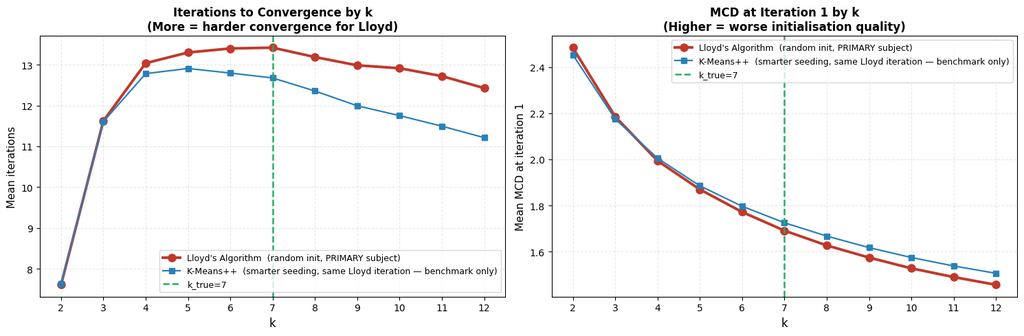

```
Figure 6 saved: fig6_convergence.png
```

```python
fig, (ax1, ax2) = plt.subplots(1, 2, figsize=(15, 5))

for algo in ['Lloyd', 'KMeansPP']:
    sub = pivot[pivot['algorithm'] == algo].sort_values('k_tested')
    ax1.plot(sub['k_tested'], sub['n_iter_avg'],
             color=COLOR[algo], marker=MARKER[algo],
             linewidth=LW[algo], markersize=8 if algo=='Lloyd' else 6,
             label=LABEL[algo])
    ax2.plot(sub['k_tested'], sub['mcd_first_avg'],
             color=COLOR[algo], marker=MARKER[algo],
             linewidth=LW[algo], markersize=8 if algo=='Lloyd' else 6,
             label=LABEL[algo])

for ax, title, ylabel in zip(
    [ax1, ax2],
    ["Iterations to Convergence by k\n(More = harder convergence for Lloyd)",
     "MCD at Iteration 1 by k\n(Higher = worse initialisation quality)"],
    ['Mean iterations', 'Mean MCD at iteration 1']
):
    ax.axvline(K_TRUE, color='#27AE60', linestyle='--', linewidth=1.8, label=f'k_true={K_TRUE}')
    ax.set_xlabel('k', fontsize=12)
    ax.set_ylabel(ylabel, fontsize=11)
    ax.set_title(title, fontsize=12, fontweight='bold')
    ax.set_xticks(K_RANGE); ax.legend(fontsize=9); ax.grid(True, alpha=0.3, linestyle='--')

plt.tight_layout()
plt.savefig('fig6_convergence.png', dpi=150, bbox_inches='tight')
plt.show()
print("Figure 6 saved: fig6_convergence.png")
```

## 11. Quantitative Findings — Lloyd's Algorithm Analysis

```python
print("=" * 75)
print("  LLOYD'S ALGORITHM STALLING — QUANTITATIVE FINDINGS")
print(f"  Polish Supermarket POS Data | {N_MONTE:,} MC replications per condition")
print("=" * 75)

lloyd_p = pivot[pivot['algorithm'] == 'Lloyd'].sort_values('k_tested')
kmpp_p  = pivot[pivot['algorithm'] == 'KMeansPP'].sort_values('k_tested')
ck_l    = lloyd_p[lloyd_p['k_tested'] == K_TRUE].iloc[0]
ck_k    = kmpp_p[kmpp_p['k_tested'] == K_TRUE].iloc[0]

print(f"\n1. LLOYD BIAS AT CORRECT k={K_TRUE} (reference = 1.0 by construction):")
print(f"   Lloyd mean bias  : {ck_l['lloyd_bias_mean']:.4f} ± {ck_l['lloyd_bias_std']:.4f}")
print(f"   KMeans++ bias    : {ck_k['lloyd_bias_mean']:.4f}  (vs same Lloyd reference)")
print(f"   Interpretation   : K-Means++ achieves {(1-ck_k['lloyd_bias_mean'])*100:.1f}% lower")
print(f"                      MCD than Lloyd at correct-k")

print(f"\n2. STALL RATES AT CORRECT k={K_TRUE}:")
print(f"   Lloyd within-condition stall  : {ck_l['stall_rate_mean']*100:.1f}% of runs")
print(f"   Lloyd referenced stall        : {ck_l['lloyd_stall_mean']*100:.1f}% of runs")
print(f"   KMeans++ within-cond stall    : {ck_k['stall_rate_mean']*100:.1f}% of runs")
if ck_l['stall_rate_mean'] > 0:
    red = (ck_l['stall_rate_mean'] - ck_k['stall_rate_mean']) / ck_l['stall_rate_mean'] * 100
    print(f"   Stall reduction with KM++     : {red:.1f}%")

under = lloyd_p[lloyd_p['k_tested'] < K_TRUE]
over  = lloyd_p[lloyd_p['k_tested'] > K_TRUE]
print(f"\n3. LLOYD BIAS ACROSS REGIONS:")
print(f"   Under-k (k<{K_TRUE}): bias {under['lloyd_bias_mean'].min():.4f} to {under['lloyd_bias_mean'].max():.4f}")
print(f"     -> High bias: each centroid covers more data, more iteration needed")
print(f"   Correct-k (k={K_TRUE}): bias = 1.0000 by construction (reference)")
print(f"   Over-k  (k>{K_TRUE}): bias {over['lloyd_bias_mean'].min():.4f} to {over['lloyd_bias_mean'].max():.4f}")
print(f"     -> Low bias: many small tight clusters, centroids barely move")
print(f"     -> BUT stall rate rises because more solutions exist to get trapped in")

print(f"\n4. SOLUTION CONSISTENCY — Cross-Run ARI (Lloyd only):")
for k_val in [2, K_TRUE, 12]:
    row = lloyd_p[lloyd_p['k_tested'] == k_val].iloc[0]
    print(f"   k={k_val:2d}: ARI = {row['ari_cross_mean']:.4f}  "
          f"stall={row['stall_rate_mean']*100:.1f}%  "
          f"bias={row['lloyd_bias_mean']:.4f}")

ari2  = lloyd_p[lloyd_p['k_tested'] == 2 ]['ari_cross_mean'].values[0]
ari12 = lloyd_p[lloyd_p['k_tested'] == 12]['ari_cross_mean'].values[0]
print(f"   ARI drop k=2 to k=12: {ari2:.4f} -> {ari12:.4f}  (collapse of {ari2-ari12:.4f})")

print(f"\n5. MCD VARIABILITY (CV across {N_MONTE:,} runs):")
print(f"   {'k':>3}  {'Lloyd MCD_CV':>14}  {'KM++ MCD_CV':>12}  {'Diff':>6}")
for k_val in K_RANGE:
    rl = lloyd_p[lloyd_p['k_tested']==k_val]['mcd_cv_mean'].values[0]
    rk = kmpp_p [kmpp_p ['k_tested']==k_val]['mcd_cv_mean'].values[0]
    print(f"   {k_val:>3}  {rl:>14.6f}  {rk:>12.6f}  {rl-rk:>+.6f}")

print("\n" + "=" * 75)
```

[output not shown]

## 12. Dissertation Write-Up Notes

### Algorithm framing

> *"Lloyd's algorithm (Lloyd, 1957, published 1982; MacQueen, 1967) is the classical K-Means procedure: centroids are initialised uniformly at random, then iteratively updated via assignment-and-recomputation until convergence. Because the within-cluster sum-of-squares objective is non-convex, Lloyd's algorithm is only guaranteed to converge to a local minimum. This experiment treats Lloyd's algorithm as its primary subject, running each condition with `n_init=1` so that single-initialisation stalling is observed directly, without the masking effect of multi-start heuristics. K-Means++ (Arthur & Vassilvitskii, 2007) serves as a benchmark: it improves the quality of initial centroid placement while leaving Lloyd's assignment-and-update iteration unchanged, enabling a controlled comparison of initialisation strategy alone."*

### Bias definition for thesis

> *"Lloyd Bias is defined as:*

> **Lloyd_bias(k) = mean_MCD_Lloyd(k) / mean_MCD_Lloyd(k_true)**

> *where MCD (Mean Centroid Displacement) is the average Euclidean distance each centroid moves per Lloyd iteration, averaged across all iterations of a single run, and then averaged across 1,000 Monte Carlo replications. The denominator is Lloyd's own mean MCD at the true number of clusters k_true = 7, pre-computed over the same 1,000-replication Monte Carlo. A bias value greater than 1.0 indicates that Lloyd's algorithm at k demands proportionally more centroid movement than at the correct-k baseline, reflecting either under-segmentation (too few clusters forcing each centroid to span a large, heterogeneous region) or poor initialisation trapping centroids in distant starting positions. A bias below 1.0 indicates over-segmentation — artificial fragmentation into many small, tight clusters where centroids barely need to move."*

### Dataset citation

> Antczak, T.; Weron, R. POS Transaction Data from a Supermarket in Southern Poland. *Data* **2019**, *4*(2), 67. https://doi.org/10.3390/data4020067

### To run this notebook

```
# Place all three CSV files in the same directory as this notebook, then:
jupyter notebook Lloyd_KMeans_Poland_POS_v3.ipynb
```

### Scaling notes

- `N_MONTE = 1000` is set for publication-grade results
- The custom `run_lloyd()` implementation is intentionally unoptimised for transparency
- For faster execution: use `sklearn.cluster.KMeans` with `n_init=1` (sacrifices MCD tracking)
- For HPC parallelisation:

```
from joblib import Parallel, delayed
reps = Parallel(n_jobs=-1)(
    delayed(run_lloyd)(X, k, LLOYD_INIT, rep, MAX_ITER)
    for rep in range(N_MONTE)
)
```